# Example using the cbenefit package

Theodor Adrian Balan

2018-10-03

# Installing and loading the package

`cbenefit` development version can be installed with:

```r
devtools::install_github("tbalan/cbenefit")
```

Sometimes, to make sure that the vignettes are built, you have to use the option `build_vignettes = TRUE`. Then the packages is loaded in the usual way:

```r
library(cbenefit)
```

# An example data set

A toy data set is included with `cbenefit`:

```r
data("dat_toy")
head(dat_toy)
> # A tibble: 6 x 11
>   treat     x1     x2     x3     x4     x5     x6     x7     x8 status
>   <int>  <dbl>  <dbl>  <dbl>  <dbl>  <dbl>  <dbl>  <dbl>  <dbl>  <dbl>
> 1     1  0.640 -0.474  0.778  0.898 -0.818  0.267 -0.138 -0.113      0
> 2     0 -0.360 -0.474 -0.222 -0.102  0.182  0.267 -0.138  0.887      0
> 3     0 -0.360 -0.474 -0.222 -0.102  0.182  0.267 -0.138 -0.113      0
> 4     0  0.640  0.526 -0.222 -0.102  0.182  0.267 -0.138 -0.113      0
> 5     0 -0.360 -0.474 -0.222 -0.102  0.182  0.267 -0.138 -0.113      0
> 6     0 -0.360 -0.474 -0.222 -0.102  0.182 -0.733 -0.138  0.887      0
> # ... with 1 more variable: time <dbl>
```

## Fitting models

Non-penalized models are fitted with the `model_fit` function:

```r
# Cox model, wrapper around coxph()
model_fit(Surv(time, status) ~  treat + x1 + x2 + x3 + x4 + x5 + x6 + x7 + x8,
dat_toy, model = "coxph")
> Call:
> survival::coxph(formula = formula, data = data, model = TRUE)
>
>         coef exp(coef) se(coef)     z      p
> treat -0.645     0.525    0.210 -3.07 0.0022
> x1     0.147     1.159    0.208  0.71 0.4781
> x2     0.472     1.604    0.211  2.24 0.0250
> x3     0.498     1.646    0.215  2.31 0.0206
> x4     0.751     2.119    0.251  2.99 0.0028
> x5     1.160     3.190    0.393  2.95 0.0031
> x6     0.364     1.439    0.289  1.26 0.2075
> x7    -0.250     0.779    0.300 -0.83 0.4051
> x8     0.709     2.031    0.249  2.85 0.0044
>
> Likelihood ratio test=59.94  on 9 df, p=1e-09
> n= 1493, number of events= 100

# Logistic regression, wrapper around glm()
model_fit(status ~ treat +  x1 + x2 + x3 + x4 + x5 + x6 + x7 + x8,
          dat_toy, model = "glm")
>
> Call:  glm(formula = formula, family = binomial(), data = data)
>
> Coefficients:
> (Intercept)        treat           x1           x2           x3
>     -2.6078      -0.6548       0.1197       0.6138       0.5683
>          x4           x5           x6           x7           x8
>      0.7880       1.2032       0.5375      -0.2214       0.7415
>
> Degrees of Freedom: 1492 Total (i.e. Null);  1483 Residual
> Null Deviance:        733.8
> Residual Deviance: 670    AIC: 690
```

Penalized models are fitted with the `model_fit_glmnet` function. Note that here also the treatment name must be specified. The resulting object of class `c_glmnet` contains, in addition to the `cv.glmnet` result, 4 fields: `x` (the model matrix), `x_other` (the model matrix, with the treatment switched), `y` (the outcome, a numeric vector for `glm` or a `Surv` object for `coxph`). this is needed because `cv.glmnet` do not easily provide a model frame for further calculations.

```r
# survival, ridge
model_fit_glmnet(Surv(time, status) ~  treat + x1 + x2 + x3 + x4 + x5 + x6 + x7 + x8,
dat_toy, model = "coxph", pen = "ridge", treat_name = "treat")

# survival, lasso
model_fit_glmnet(Surv(time, status) ~  treat + x1 + x2 + x3 + x4 + x5 + x6 + x7 + x8,
dat_toy, model = "coxph", pen = "lasso", treat_name = "treat")

# logistic, ridge
model_fit_glmnet(status ~  treat + x1 + x2 + x3 + x4 + x5 + x6 + x7 + x8,
dat_toy, model = "glm", pen = "ridge", treat_name = "treat")

# logistic, lasso
model_fit_glmnet(status ~  treat + x1 + x2 + x3 + x4 + x5 + x6 + x7 + x8,
dat_toy, model = "glm", pen = "lasso", treat_name = "treat")
```

You can get a data frame with the estimated coefficients using the `coef_cbenefit` function:

```r
m1 <- model_fit(Surv(time, status) ~  treat + x1 + x2 + x3 + x4 + x5 + x6 + x7 + x8,
dat_toy, model = "coxph")

m2 <- model_fit_glmnet(status ~  treat + x1 + x2 + x3 + x4 + x5 + x6 + x7 + x8,
dat_toy, model = "glm", pen = "lasso", treat_name = "treat")

coef_cbenefit(m1)
> # A tibble: 9 x 7
>   term  estimate std.error statistic p.value conf.low conf.high
>   <chr>    <dbl>     <dbl>     <dbl>   <dbl>    <dbl>     <dbl>
> 1 treat   -0.645     0.210    -3.07  0.00217  -1.06      -0.233
> 2 x1       0.147     0.208     0.709 0.478    -0.260      0.555
> 3 x2       0.472     0.211     2.24  0.0250    0.0593     0.886
> 4 x3       0.498     0.215     2.31  0.0206    0.0764     0.920
> 5 x4       0.751     0.251     2.99  0.00278   0.259      1.24
> 6 x5       1.16      0.393     2.95  0.00313   0.390      1.93
> 7 x6       0.364     0.289     1.26  0.208    -0.202      0.929
> 8 x7      -0.250     0.300    -0.833 0.405    -0.839      0.339
> 9 x8       0.709     0.249     2.85  0.00437   0.221      1.20
coef_cbenefit(m2)
>           term    estimate
> 1  (Intercept) -2.55236002
> 2        treat -0.65372151
> 3           x1  0.07168904
> 4           x2  0.54532420
> 5           x3  0.51604204
> 6           x4  0.73470159
> 7           x5  1.01043629
> 8           x6  0.45197257
> 9           x7 -0.08992974
> 10          x8  0.68902334
```

## Calculating c index and c for benefit

```r
mod <- model_fit(Surv(time, status) ~  treat + x1 + x2 + x3 + x4 + x5 + x6 + x7 + x8,
dat_toy, model = "coxph")
```

The function that does most work is `benefit_cv`. Two important parameters here: `folds` is the number of folds for the *k*-fold cross validation and `times` is the number of times that the cross-validation process is repeated. For example, five times *k*-fold cross validation:

```r
bb <- benefit_cv(mod, "treat", folds = 10, times = 5)

bb
> Object of type cbenefit
> Event rate control group: 0.119
> Event rate treatment group: 0.074
> c-statistics:
>          c      c_ben e_mean_ben   e_90_ben
> 0.73532291 0.59185210 0.01913734 0.02706710
>
> average c-statistics (from 5 CV):
>          c      c_ben e_mean_ben   e_90_ben
> 0.70194490 0.50491680 0.02737605 0.07689330
>
> c-statistics on averaged probabilities (from 5 CV):
>          c      c_ben e_mean_ben   e_90_ben
> 0.70220917 0.51156530 0.02555004 0.04671063
```

All three fields contain: the c-index (aka c-statistic), the c-for-benefit statustic (van Klaveren et al, 2018), and the E-mean and E-90 statistics for benefit. The first part is without corss validation. The “average c-statistics” are obtained by calculating them at each iteration of the cross-validation and then averaging. The “c-statistics on averaged probabilities” are obtained by calculating the statistics on the average of the predicted probabilities from each iteration of the cross-validation.

An option that was not used here is the `reproducible` option. For example, check this out with only cross-validation happening once:

```r
bb <- benefit_cv(mod, "treat", folds = 10, times = 1)

bb
> Object of type cbenefit
> Event rate control group: 0.119
> Event rate treatment group: 0.074
> c-statistics:
>          c      c_ben e_mean_ben   e_90_ben
> 0.73532291 0.56845759 0.01896527 0.03181009
>
> average c-statistics (from 1 CV):
>          c      c_ben e_mean_ben   e_90_ben
> 0.70478526 0.53241219 0.02367952 0.04571576
>
> c-statistics on averaged probabilities (from 1 CV):
>          c      c_ben e_mean_ben   e_90_ben
> 0.70478526 0.50655558 0.02394553 0.05023120
```

There is usually a difference between the two cross-validatated benefit indexes, although they should be equal. The reason for this is that the matching of the individuals actually happens mode times: once (before cross-validation), `times` times, for each cross-validation iteration, and again once at the end on the averaged probabilities. This matching is usually stochastic and it messes with the current seed (no option to change that in `MatchIt`). The other source of randomness comes from calculating the folds in the cross-validation. So what if you want to actually replicate your results? A sort-of-solution is to use the `reproducible = TRUE` option:

```r
bb <- benefit_cv(mod, "treat", folds = 10, times = 1, reproducible = TRUE)

bb
> Object of type cbenefit
> Event rate control group: 0.119
> Event rate treatment group: 0.074
> c-statistics:
>          c      c_ben e_mean_ben   e_90_ben
> 0.73532291 0.58769347 0.01676042 0.03195503
>
> average c-statistics (from 1 CV):
>          c      c_ben e_mean_ben   e_90_ben
> 0.69173844 0.51128187 0.02123426 0.06484428
>
> c-statistics on averaged probabilities (from 1 CV):
>          c      c_ben e_mean_ben   e_90_ben
> 0.69173844 0.51128187 0.02123426 0.06484428
```

The way that this works is as follows - the first matching happens with `set.seed(1)`. - iteration `i` of the cross-validation starts with `set.seed(i)` - before each matching at iteration `i`, `set.seed(i)` is called again - the last matching (on the average predicted probabilities) is preceded by a `set.seed(1)`

### Experimental features

- Do you prefer matching by covariates instead of the default (predicted benefit)? Set the argument `match_by = "covariates"` and specify the data frame where the model was fitted. Should work but did not test it a lot.

```r
mcv <- benefit_cv(mod, "treat", folds = 10, times = 1, match_by = "covariates", data = dat_toy)
mcv
> Object of type cbenefit
> Event rate control group: 0.119
> Event rate treatment group: 0.074
> c-statistics:
>          c      c_ben e_mean_ben   e_90_ben
> 0.73532291 0.56295194 0.02398618 0.04847607
>
> average c-statistics (from 1 CV):
>          c      c_ben e_mean_ben   e_90_ben
> 0.69311204 0.50617878 0.02745226 0.07275816
>
> c-statistics on averaged probabilities (from 1 CV):
>          c      c_ben e_mean_ben   e_90_ben
> 0.69311204 0.50617878 0.02745226 0.07275816
```

You will see that here the c for benefits are exact: the reason is that this matching does no have to be re-calculated every time (since it only depends on covariates).

- Do you want to change the way individuals are matched? Then you can use the `...` argumnet to pass on to `MatchIt::matchit`. Check out the documentation of that function for more details. At this moment overriding “method” does not seem to work, since `matchit` does not provide a match matrix for other methods. Will look further into this.

```r
matchb <- benefit_cv(mod, "treat", folds = 10, times = 1, matchit_args = list(distance = "mahalanobis"))

matchc <- benefit_cv(mod, "treat", folds = 10, times = 1, matchit_args = list(distance = "cloglog"))
```

## Calibration and net benefit plots

Calibration plots and net benefit plots are obtained with the `calibration_plot()` and `net_benefit_plot()` functions. They each return a list of two `ggplot` objects: one without cross validation, one after cross-validation. For these plots the probabilities that are averaged from all the iterations of the cross validation are used.

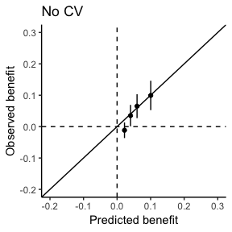

```r
cp <- calibration_plot(bb)
nb <- net_benefit_plot(bb)

library(ggplot2)
cp$caplot_nocv
```

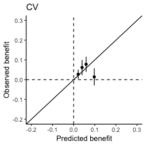

```r
cp$caplot_cv
```

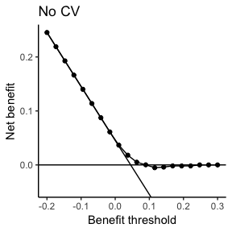

```r
nb$nbplot_nocv
```

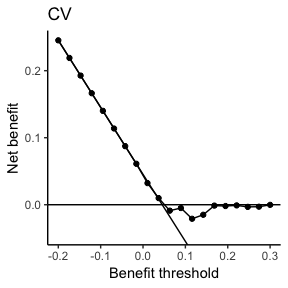

```r
nb$nbplot_cv
```

You can also put them all in one plot with the package `egg`:

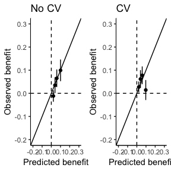

```r
library(egg)
> Loading required package: gridExtra
ggarrange(plots = cp, nrow = 1)
```

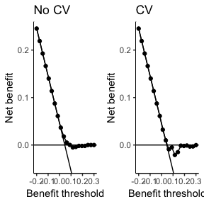

```r
ggarrange(plots = nb, nrow = 1)
```

# Playing with formulas

## Parameters to be specified

```r
model <- "coxph"
# at the formula, just specify it without interactions, just the variables you want in
formula <- Surv(time, status) ~ treat + x1 + x2 + x3 + x4 + x5 + x6 + x7 + x8
dataset <- "dat_toy"
treat_name <- "treat"
model = "coxph"
```

Now we can manipulate the formula in whichever way we want:

```r
library(rms) # need it for rcs
> Loading required package: Hmisc
> Loading required package: lattice
> Loading required package: survival
> Loading required package: Formula
>
> Attaching package: 'Hmisc'
> The following objects are masked from 'package:base':
>
>     format.pval, units
> Loading required package: SparseM
>
> Attaching package: 'SparseM'
> The following object is masked from 'package:base':
>
>     backsolve

# get the names of all the variables
allvars <- attr(terms(formula), "term.labels")

# model for prognostic index, without treatment
model_pi <- model_fit(formula = as.formula(paste0(formula[2], "~", paste0(setdiff(allvars, treat_name), collapse = "+"))),
                      model = model,
                      data = dataset)

# get prognostic index
pi <- scale(predict(model_pi, type = "lp"), center = TRUE, scale = FALSE)
pi_rcs <- as.vector(rcs(pi, 3)[,2])

# constant relative treatment effect
model_rte <- model_fit(formula = formula,
                       model = model,
                       data = dataset)

# treatment interaction with prognostic index
model_treat_pi <- model_fit(model = model,
                            formula = as.formula(paste0(formula[2], "~", paste0(treat_name, "*", "pi"))),
                            data = dataset)

# treatment interaction with cubic splines
model_treat_pi_rcs <- model_fit(model = model,
                            formula = as.formula(paste0(formula[2], "~", paste0(treat_name, "*", "(pi + pi_rcs)"))),
                            data = dataset)

# all interactions
model_treat_int <- model_fit(model = model,
                             formula = as.formula(paste0(formula[2], "~", treat_name, " * (",paste0(setdiff(allvars, treat_name), collapse = "+"),")")),
                             data = dataset)

# ridge, all interactions
model_ridge <- model_fit_glmnet(formula = as.formula(paste0(formula[2], "~", treat_name, " * (",paste0(setdiff(allvars, treat_name), collapse = "+"),")")),
                                model = model,
                             pen = "ridge",
                             treat_name = treat_name,
                             data = dataset)

# lasso, all interactions
model_lasso <- model_fit_glmnet(
                             formula = as.formula(paste0(formula[2], "~", treat_name, " * (",paste0(setdiff(allvars, treat_name), collapse = "+"),")")),
                             model = model,
                             pen = "lasso",
                             treat_name = treat_name,
                             data = dataset)
```

Now that all the models are fitted, we can run cross validation on all of them:

```r
models <- list(#pi = model_pi,
               rte = model_rte,
               treat_pi = model_treat_pi,
               treat_pi_rcs = model_treat_pi_rcs,
               treat_allint = model_treat_int,
               ridge = model_ridge,
               lasso = model_lasso)

# repeat only 3 times cross validation, to be quick here
res <- lapply(models, benefit_cv, folds = 10, times = 3, reproducible = TRUE, treat_name = "treat")
```

And now an example how to print all this stuff nicely:

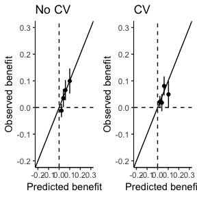

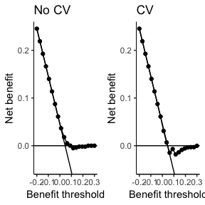

```
>
>
>
>
> term       estimate   std.error    statistic     p.value     conf.low    conf.high
> ------  -----------  ----------  -----------  ----------  -----------  -----------
> treat    -0.6447367   0.2102591   -3.0663911   0.0021666   -1.0568370   -0.2326364
> x1        0.1473469   0.2077359    0.7092992   0.4781388   -0.2598080    0.5545018
> x2        0.4724014   0.2107907    2.2410926   0.0250201    0.0592593    0.8855435
> x3        0.4984256   0.2153031    2.3149949   0.0206132    0.0764393    0.9204120
> x4        0.7509846   0.2510903    2.9908947   0.0027816    0.2588567    1.2431125
> x5        1.1599611   0.3926397    2.9542632   0.0031342    0.3904014    1.9295209
> x6        0.3637364   0.2885731    1.2604655   0.2075015   -0.2018564    0.9293293
> x7       -0.2501480   0.3004744   -0.8325102   0.4051210   -0.8390670    0.3387710
> x8        0.7085679   0.2486093    2.8501263   0.0043702    0.2213026    1.1958332
>
>
> Object of type cbenefit
> Event rate control group: 0.119
> Event rate treatment group: 0.074
> c-statistics:
>          c      c_ben e_mean_ben   e_90_ben
> 0.73465750 0.57559112 0.02613047 0.03965196
>
> average c-statistics (from 3 CV):
>          c      c_ben e_mean_ben   e_90_ben
> 0.72204953 0.52691580 0.02479787 0.05187772
>
> c-statistics on averaged probabilities (from 3 CV):
>          c      c_ben e_mean_ben   e_90_ben
> 0.72138729 0.54817547 0.02153491 0.02674330
```

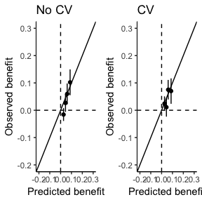

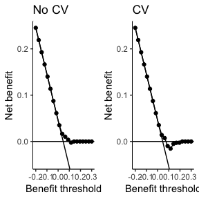

```
>
>
>
>
> term       estimate   std.error    statistic     p.value     conf.low    conf.high
> ------  -----------  ----------  -----------  ----------  -----------  -----------
> treat    -0.6447367   0.2102591   -3.0663911   0.0021666   -1.0568370   -0.2326364
> x1        0.1473469   0.2077359    0.7092992   0.4781388   -0.2598080    0.5545018
> x2        0.4724014   0.2107907    2.2410926   0.0250201    0.0592593    0.8855435
> x3        0.4984256   0.2153031    2.3149949   0.0206132    0.0764393    0.9204120
> x4        0.7509846   0.2510903    2.9908947   0.0027816    0.2588567    1.2431125
> x5        1.1599611   0.3926397    2.9542632   0.0031342    0.3904014    1.9295209
> x6        0.3637364   0.2885731    1.2604655   0.2075015   -0.2018564    0.9293293
> x7       -0.2501480   0.3004744   -0.8325102   0.4051210   -0.8390670    0.3387710
> x8        0.7085679   0.2486093    2.8501263   0.0043702    0.2213026    1.1958332
>
>
> Object of type cbenefit
> Event rate control group: 0.119
> Event rate treatment group: 0.074
> c-statistics:
>          c      c_ben e_mean_ben   e_90_ben
> 0.73776593 0.59130871 0.01723553 0.03039940
>
> average c-statistics (from 3 CV):
>          c      c_ben e_mean_ben   e_90_ben
> 0.72142848 0.50998626 0.03450524 0.06986622
>
> c-statistics on averaged probabilities (from 3 CV):
>          c      c_ben e_mean_ben   e_90_ben
> 0.72081694 0.51529617 0.04258627 0.06749320
```

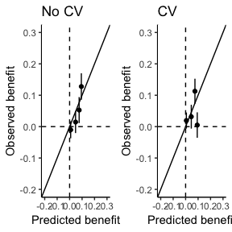

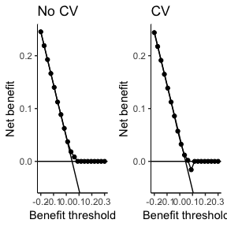

```
>
>
>
>
> term       estimate   std.error    statistic     p.value     conf.low    conf.high
> ------  -----------  ----------  -----------  ----------  -----------  -----------
> treat    -0.6447367   0.2102591   -3.0663911   0.0021666   -1.0568370   -0.2326364
> x1        0.1473469   0.2077359    0.7092992   0.4781388   -0.2598080    0.5545018
> x2        0.4724014   0.2107907    2.2410926   0.0250201    0.0592593    0.8855435
> x3        0.4984256   0.2153031    2.3149949   0.0206132    0.0764393    0.9204120
> x4        0.7509846   0.2510903    2.9908947   0.0027816    0.2588567    1.2431125
> x5        1.1599611   0.3926397    2.9542632   0.0031342    0.3904014    1.9295209
> x6        0.3637364   0.2885731    1.2604655   0.2075015   -0.2018564    0.9293293
> x7       -0.2501480   0.3004744   -0.8325102   0.4051210   -0.8390670    0.3387710
> x8        0.7085679   0.2486093    2.8501263   0.0043702    0.2213026    1.1958332
>
>
> Object of type cbenefit
> Event rate control group: 0.119
> Event rate treatment group: 0.074
> c-statistics:
>          c      c_ben e_mean_ben   e_90_ben
> 0.74304169 0.60588855 0.02070966 0.03161735
>
> average c-statistics (from 3 CV):
>          c      c_ben e_mean_ben   e_90_ben
> 0.67080331 0.45523412 0.04429241 0.10028621
>
> c-statistics on averaged probabilities (from 3 CV):
>          c      c_ben e_mean_ben   e_90_ben
> 0.66977034 0.44504583 0.04400732 0.12959611
```

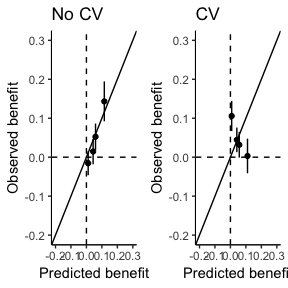

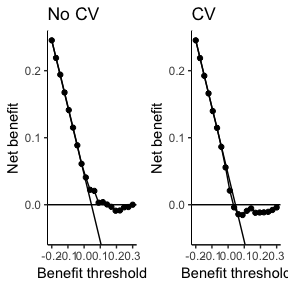

```
>
>
>
>
> term       estimate   std.error    statistic     p.value     conf.low    conf.high
> ------  -----------  ----------  -----------  ----------  -----------  -----------
> treat    -0.6447367   0.2102591   -3.0663911   0.0021666   -1.0568370   -0.2326364
> x1        0.1473469   0.2077359    0.7092992   0.4781388   -0.2598080    0.5545018
> x2        0.4724014   0.2107907    2.2410926   0.0250201    0.0592593    0.8855435
> x3        0.4984256   0.2153031    2.3149949   0.0206132    0.0764393    0.9204120
> x4        0.7509846   0.2510903    2.9908947   0.0027816    0.2588567    1.2431125
> x5        1.1599611   0.3926397    2.9542632   0.0031342    0.3904014    1.9295209
> x6        0.3637364   0.2885731    1.2604655   0.2075015   -0.2018564    0.9293293
> x7       -0.2501480   0.3004744   -0.8325102   0.4051210   -0.8390670    0.3387710
> x8        0.7085679   0.2486093    2.8501263   0.0043702    0.2213026    1.1958332
>
>
> Object of type cbenefit
> Event rate control group: 0.119
> Event rate treatment group: 0.074
> c-statistics:
>          c      c_ben e_mean_ben   e_90_ben
> 0.74201506 0.45301719 0.02126905 0.03422849
>
> average c-statistics (from 3 CV):
>          c      c_ben e_mean_ben   e_90_ben
> 0.69181765 0.44813772 0.02812111 0.05812673
>
> c-statistics on averaged probabilities (from 3 CV):
>          c      c_ben e_mean_ben   e_90_ben
> 0.69343048 0.46690752 0.02118753 0.04118921
```

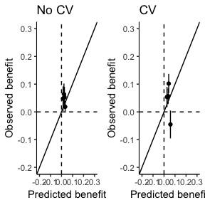

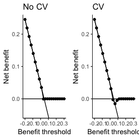

```
>
>
>
>
> term       estimate   std.error    statistic     p.value     conf.low    conf.high
> ------  -----------  ----------  -----------  ----------  -----------  -----------
> treat    -0.6447367   0.2102591   -3.0663911   0.0021666   -1.0568370   -0.2326364
> x1        0.1473469   0.2077359    0.7092992   0.4781388   -0.2598080    0.5545018
> x2        0.4724014   0.2107907    2.2410926   0.0250201    0.0592593    0.8855435
> x3        0.4984256   0.2153031    2.3149949   0.0206132    0.0764393    0.9204120
> x4        0.7509846   0.2510903    2.9908947   0.0027816    0.2588567    1.2431125
> x5        1.1599611   0.3926397    2.9542632   0.0031342    0.3904014    1.9295209
> x6        0.3637364   0.2885731    1.2604655   0.2075015   -0.2018564    0.9293293
> x7       -0.2501480   0.3004744   -0.8325102   0.4051210   -0.8390670    0.3387710
> x8        0.7085679   0.2486093    2.8501263   0.0043702    0.2213026    1.1958332
>
>
> Object of type cbenefit
> Event rate control group: 0.119
> Event rate treatment group: 0.074
> c-statistics:
>          c      c_ben e_mean_ben   e_90_ben
> 0.73984772 0.54259167 0.01779232 0.03181036
>
> average c-statistics (from 3 CV):
>          c      c_ben e_mean_ben   e_90_ben
> 0.68456783 0.45397236 0.02959242 0.06496637
>
> c-statistics on averaged probabilities (from 3 CV):
>          c      c_ben e_mean_ben   e_90_ben
> 0.68686192 0.47505043 0.01966154 0.04708451
```

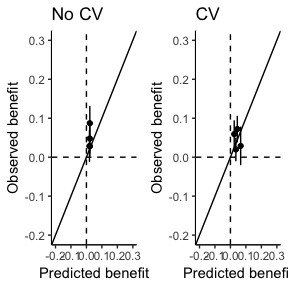

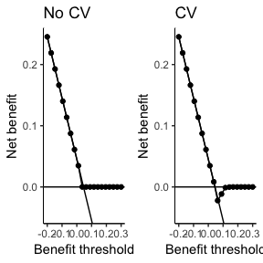

```r
library(pander)
library(egg)
library(broom)

cat_asis <- function(x) knitr::asis_output(capture.output(x))


for(i in 1:length(models)) {

  cat_asis(pandoc.header(names(models)[i], level = 2))
  #knitr::asis_outputpandoc.header(names(models)[i], level = 2)

  cat_asis(pandoc.header("Estimates", level = 3))

  cat("\n")

  print(knitr::kable(coef_cbenefit(models[[1]])))

  cat("\n")

  cat_asis(pandoc.header("C for benefit", level = 3))

  cat("\n")
  print(res[[i]])

  cat("\n")

  cat_asis(pandoc.verbatim(print(res[[i]])))

  cat("\n")

  cat_asis(pandoc.header("Plots", level = 3))

  ggarrange(plots = calibration_plot(res[[i]]), nrow = 1)
  ggarrange(plots = net_benefit_plot(res[[i]]), nrow = 1)

  cat("\n")
}
>
>
>
> term       estimate   std.error    statistic     p.value     conf.low    conf.high
> ------  -----------  ----------  -----------  ----------  -----------  -----------
> treat    -0.6447367   0.2102591   -3.0663911   0.0021666   -1.0568370   -0.2326364
> x1        0.1473469   0.2077359    0.7092992   0.4781388   -0.2598080    0.5545018
> x2        0.4724014   0.2107907    2.2410926   0.0250201    0.0592593    0.8855435
> x3        0.4984256   0.2153031    2.3149949   0.0206132    0.0764393    0.9204120
> x4        0.7509846   0.2510903    2.9908947   0.0027816    0.2588567    1.2431125
> x5        1.1599611   0.3926397    2.9542632   0.0031342    0.3904014    1.9295209
> x6        0.3637364   0.2885731    1.2604655   0.2075015   -0.2018564    0.9293293
> x7       -0.2501480   0.3004744   -0.8325102   0.4051210   -0.8390670    0.3387710
> x8        0.7085679   0.2486093    2.8501263   0.0043702    0.2213026    1.1958332
>
>
> Object of type cbenefit
> Event rate control group: 0.119
> Event rate treatment group: 0.074
> c-statistics:
>          c      c_ben e_mean_ben   e_90_ben
> 0.73532291 0.58769347 0.01676042 0.03195503
>
> average c-statistics (from 3 CV):
>          c      c_ben e_mean_ben   e_90_ben
> 0.69489122 0.51536724 0.02451621 0.06431566
>
> c-statistics on averaged probabilities (from 3 CV):
>          c      c_ben e_mean_ben   e_90_ben
> 0.69656743 0.49566912 0.03088424 0.08818649
```